## Introduction

In this project, we are finding out the popularity of all the national parks in the United States. Based on the number of visitors to each national park every year, we can find out the most popular national parks in the United States. We are trying to analyze the factors that might be affecting the popularity of the national park. We have identified two factors for our project, the temperature of the state in which the national park is located and the acreage of the national park for our analysis. We will try to identify if these two factors affect the popularity of the national parks or not. We are also trying to identify any patterns in the popularity of national parks with respect to these two factors.

## Project Flowchart

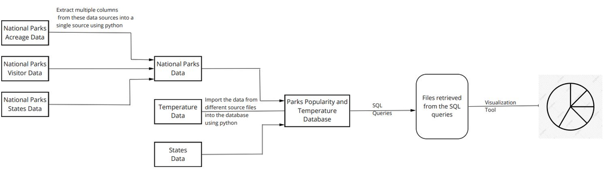

## Datasets

- **Annual Visitation To National Parks Data**  
  This dataset provided by National Park Service (NPS) contains total number of visitors for each national park in different regions of US from 1904 to 2021. This dataset is available in CSV format so we did not have to convert it.

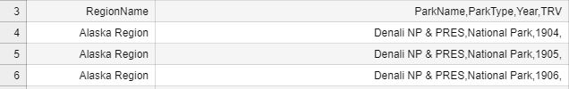

- **Recreation Visitation By State and by Park Data**  
  This dataset provided by NPS contains the number of recreation visitors and visitor days for all National Parks. It also categorizes all the national parks by the state they are present in. This dataset is available in CSV format so we did not have to convert it.

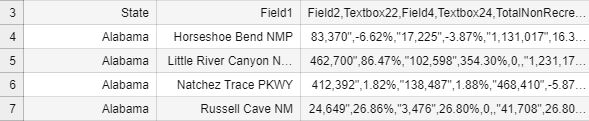

- **National Park Acreage Data**  
  This [dataset](https://www.nps.gov/subjects/lwcf/acreagereports.htm) by provided by NPS contains the acreage of all the national parks in US for various from 1997 to 2021. This dataset is available in .xlsx format so we used saved as to convert it to CSV format.

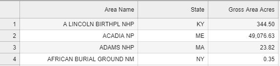

- **State Code Data**  
  This [dataset](https://www.bls.gov/respondents/mwr/electronic-data-interchange/appendix-d-usps-state-abbreviations-and-fips-codes.htm) provides us with the postal codes of different states of US. This dataset is available in HTML table format, hence we used online converter http://www.convertcsv.com/html-table-to-csv.htm to create a CSV file.

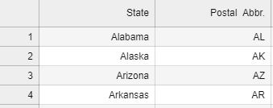

- **Temperature Data**  
  This [dataset](https://www.extremeweatherwatch.com/us-state-averages) provides the yearly average temperature for all states in the United States. It provides the average temperature over the entire territory of the state between 1991–2020. This dataset is available in HTML table format, hence we used online converter http://www.convertcsv.com/html-table-to-csv.htm to create a CSV file.

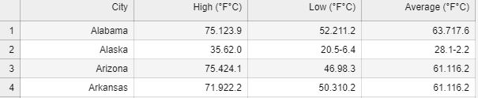

## Database Design

### ER Diagram

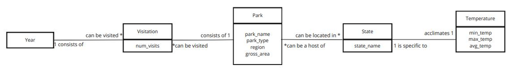

### Relational Vocabulary

Year has_many Park through Visitation  
Park has_many Year through Visitation

Visitation belongs_to Year  
Visitation belongs_to Park

Park has_and_belongs_to_many State  
State has_and_belongs_to_many Park

State belongs_to Temperature  
Temperature belongs_to State

### Sample Tables

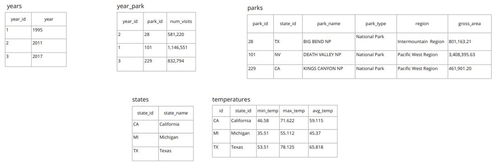

## Future Work

We would like to use a temperature data set for the national parks and not the state as that will help us analyze the trends better.